# Tugas Penanganan Kondisi Tak Standar dan Transformasi

Sintong M.N Purba - G1401221077

2024-03-05

# Pembentukan Model Awal

## Pembacaan Data

Data yang diberikan berisi 2 peubah X dan Y yang terdiri atas 15 amatan. Data terlebih dahulu dimasukkan kedalam excel kemudian dibaca menggunakan R.

```r
library(readxl)
data_model <- read_excel("C:/Users/Poerba/Documents/Data_Anreg.xlsx")
X=data_model$X
Y=data_model$Y
data_model= data.frame(X,Y)
data_model
```

```
##     X  Y
## 1   2 54
## 2   5 50
## 3   7 45
## 4  10 37
## 5  14 35
## 6  19 25
## 7  26 20
## 8  31 16
## 9  34 18
## 10 38 13
## 11 45  8
## 12 52 11
## 13 53  8
## 14 60  4
## 15 65  6
```

## Model Awal

Dibentuk model menggunakan fungsi lm sehingga didapatkan parameter $\hat\beta_0$ atau intersep dan $\hat\beta_1$ atau slope dari garis regresi

```r
model=lm(formula = Y~X, data=data_model)
summary(model)
```

```
##
## Call:
## lm(formula = Y ~ X, data = data_model)
##
## Residuals:
##     Min      1Q  Median      3Q     Max
## -7.1628 -4.7313 -0.9253  3.7386  9.0446
##
## Coefficients:
##             Estimate Std. Error t value Pr(>|t|)
## (Intercept) 46.46041    2.76218   16.82 3.33e-10 ***
## X           -0.75251    0.07502  -10.03 1.74e-07 ***
## ---
## Signif. codes:  0 '***' 0.001 '**' 0.01 '*' 0.05 '.' 0.1 ' ' 1
##
## Residual standard error: 5.891 on 13 degrees of freedom
## Multiple R-squared:  0.8856, Adjusted R-squared:  0.8768
## F-statistic: 100.6 on 1 and 13 DF,  p-value: 1.736e-07
```

Model yang didapatkan adalah
$$\hat Y=46.46041-0.75251X$$
Didapatkan juga nilai Adjusted R-squared: 0.8768

## Scatterplot

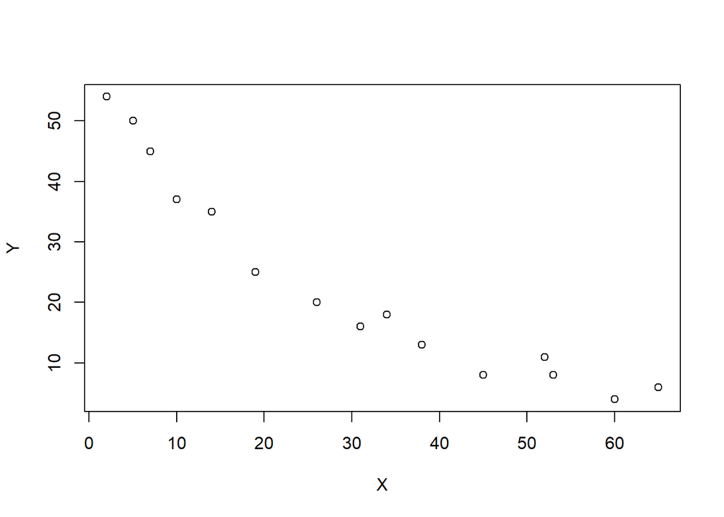

```r
plot(X,Y)
```

Pada scatter plot antara X dan Y dapat dilihat bahwa data tidak mengikuti garis linear, melainkan sedikit melengkung dimana pada model didapatkan bahwa $\hat\beta_1$ < 0, sehingga perlu transformasi dengan memperkecil variabel Y maupun variabel X.

# Pengujian Asumsi

## Pengujian nilai harapan erorr = 0

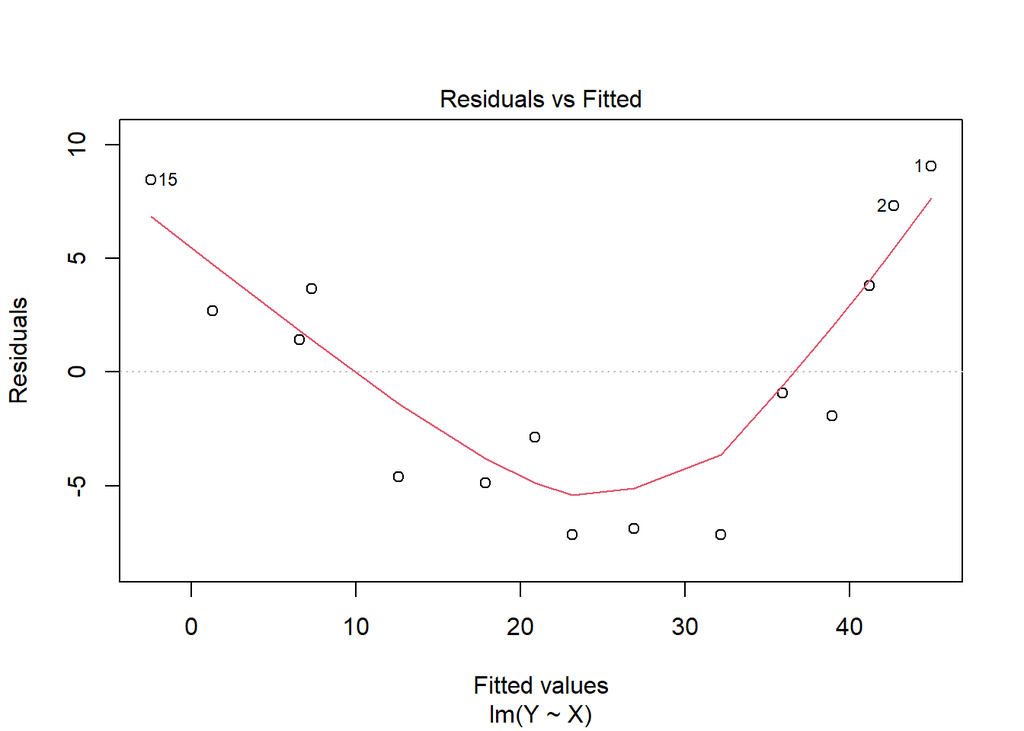

```r
plot(model,1)
```

```r
t.test(model$residuals,mu = 0,conf.level = 0.95)
```

```
##
##  One Sample t-test
##
## data:  model$residuals
## t = -4.9493e-16, df = 14, p-value = 1
## alternative hypothesis: true mean is not equal to 0
## 95 percent confidence interval:
##  -3.143811  3.143811
## sample estimates:
##     mean of x
## -7.254614e-16
```

Karena nilai p-value> 0.05 maka asumsi $E[e]=0$ terpenuhi

## Pengujian Homoscedasticity

Uji ini memiliki hipotesis sebagai berikut,

$H0:var[ϵ]=σ^2I$ (ragam homogen)

$H1:var[ϵ]≠σ^2I$ (ragam tidak homogen)

```r
library(lmtest)
bptest(model)
```

```
##
##  studentized Breusch-Pagan test
##
## data:  model
## BP = 0.52819, df = 1, p-value = 0.4674
```

Karena nilai p-value > 0.05 maka tak tolak H0, artinya tidak cukup bukti untuk menyatakan bahwa ragam sisaan tidak homogen atau asumsi Homoscedasticity terpenuhi

## Pengujian Autokorelasi Sisaan

Autokorelasi sisaan dideteksi mengggunakan uji Durbin-Watson dengan hipotesis :

$H0:E[ϵ_i,ϵ_j]=0$ (Tidak ada Autokorelasi)

$H1:E[ϵ_i,ϵ_j]≠)0$ (Ada Autokorelasi)

```r
(uji_autokol <- dwtest(model,
                                 alternative="two.sided"))
```

```
##
##  Durbin-Watson test
##
## data:  model
## DW = 0.48462, p-value = 2.665e-05
## alternative hypothesis: true autocorrelation is not 0
```

```r
ifelse(uji_autokol$p < 0.05, "Ada Autokorelasi", "Tidak Ada Autokorelasi")
```

```
## [1] "Ada Autokorelasi"
```

Dapat dilihat bahwa p-value< 0.05 sehingga tolak H0 yang mengindikasikan terdapat autokorelasi dalam sisaan

## Uji Normal

```r
library(nortest)
sisaan_model <- resid(model)
(norm_model <- lillie.test(sisaan_model))
```

```
##
##  Lilliefors (Kolmogorov-Smirnov) normality test
##
## data:  sisaan_model
## D = 0.12432, p-value = 0.7701
```

Pada uji Lilliefors (Kolmogorov-Smirnov) saat p-value> 0.05 maka sisaan akan menyebar normal, sehingga asumsi ini terpenuhi.

# Transformasi

```r
Model_Trans = lm(formula = Y~sqrt(X), data = data_model)
summary(Model_Trans)
```

```
##
## Call:
## lm(formula = Y ~ sqrt(X), data = data_model)
##
## Residuals:
##     Min      1Q  Median      3Q     Max
## -4.4518 -2.8559  0.7657  2.0035  5.2422
##
## Coefficients:
##             Estimate Std. Error t value Pr(>|t|)
## (Intercept)  63.2250     2.2712   27.84 5.67e-13 ***
## sqrt(X)      -7.7481     0.4097  -18.91 7.68e-11 ***
## ---
## Signif. codes:  0 '***' 0.001 '**' 0.01 '*' 0.05 '.' 0.1 ' ' 1
##
## Residual standard error: 3.262 on 13 degrees of freedom
## Multiple R-squared:  0.9649, Adjusted R-squared:  0.9622
## F-statistic: 357.7 on 1 and 13 DF,  p-value: 7.684e-11
```

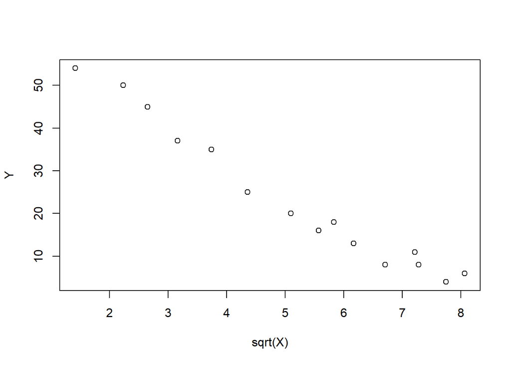

```r
plot(sqrt(X),Y)
```

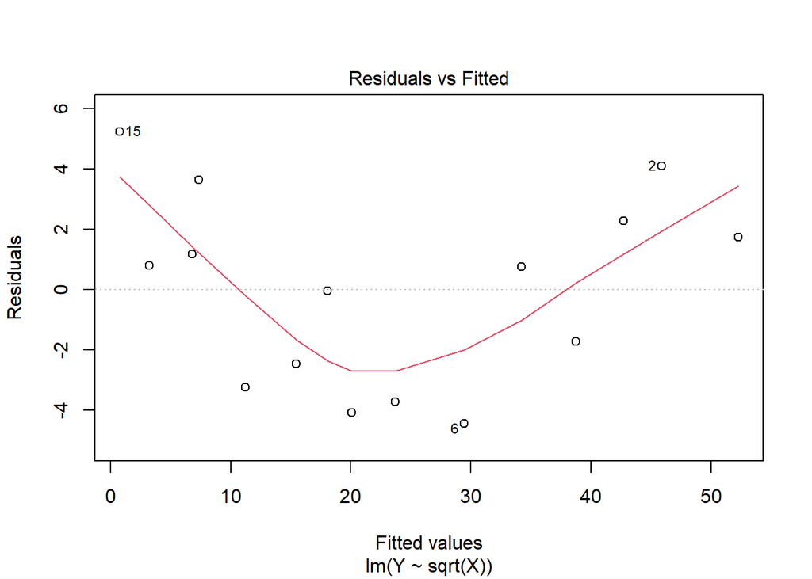

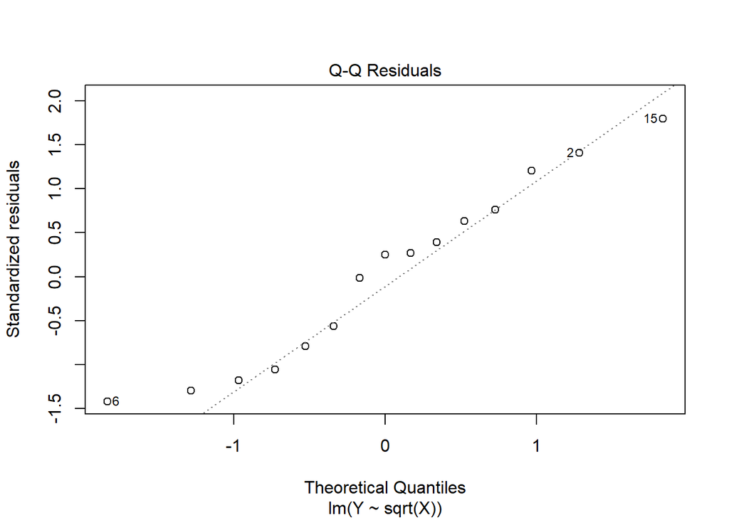

```r
plot(Model_Trans,1:2)
```

Lebar pita hampir sama untuk setiap nilai dugaan → ragam homogen

Pada QQplot juga terlihat data menyebar normal disekitar garis.

```r
library(lmtest)
bptest(Model_Trans)
```

```
##
##  studentized Breusch-Pagan test
##
## data:  Model_Trans
## BP = 0.49234, df = 1, p-value = 0.4829
```

```r
(uji_autokol <- dwtest(Model_Trans,
                                 alternative="two.sided"))
```

```
##
##  Durbin-Watson test
##
## data:  Model_Trans
## DW = 1.1236, p-value = 0.02845
## alternative hypothesis: true autocorrelation is not 0
```

```r
ifelse(uji_autokol$p < 0.05, "Ada Autokorelasi", "Tidak Ada Autokorelasi")
```

```
## [1] "Ada Autokorelasi"
```

Interpretasi :

$\beta_0$ = saat X bernilai 0 maka dugaan rataan dari nilai Y adalah sebesar 63.2250.

$\beta_1$ = Saat nilai akar X bertambah 1 satuan maka nilai dugaan dari rataan Y akan berkurang sebesar 7.7481.